# Introdução ao R - Sessão 4

Estatística descritiva e Desenvolvimento de gráficos no R

Tiago Ferreira

Novembro 4, 2020

AGENDA | Estatística descritiva e Desenvolvimento de gráficos no R

**1. Estatística descritiva univariada**  
**2. Fórmulas no R**  
**3. Estatísticas descritiva por grupos**  
**4. Visualização de distribuições**  
**5. Tabelas de frequências**  
**6. Visualização de frequências**

# 1. Estatística descritiva univariada

## Preparação da Base de dados

Recorremos à base de dados **coffee** para demonstrar algumas das funcionalidades do R ao nível da estatística descritiva univariada. Esta base de dados contem as revisões de satisfação dos clientes relativamente a 67 cafés da cidade de Austin nos EUA. Estas revisões foram exportadas da plataforma **Yelp.com**.

```r
load("G:\\My Drive\\FPCEUP\\R trainning\\GitRepo\\DRPMBE_R-Intro\\Manuais\\DATA_R1\\coffee.Rda")

head(coffee)
```

```
##                       coffee_shop_name num_reviews rating coffee  tea vibe
## 1               Manana Coffee & Juice           33   4.85   0.67 0.03 0.52
## 2                        Brian's Brew           45   4.84   0.89 0.00 0.04
## 3                       Flitch Coffee           28   4.82   0.57 0.07 0.46
## 4 Third Coast Coffee Roasting Company           56   4.82   0.75 0.00 0.16
## 5                    Kowabunga Coffee           16   4.81   0.06 0.13 0.00
## 6                       Legend Coffee           28   4.71   0.89 0.04 0.00
##   internet food alcohol seating service parking location local price hours
## 1        0 0.21    0.00    0.21    0.27    0.00     0.12 -0.03 -0.06  0.06
## 2        0 0.11    0.00    0.02    0.22    0.11     0.02  0.02  0.00  0.00
## 3        0 0.00    0.00    0.39    0.29    0.29     0.04 -0.04  0.04  0.00
## 4        0 0.04    0.04    0.00    0.21    0.05     0.04  0.07  0.18  0.04
## 5        0 0.00    0.00    0.00    0.44    0.00     0.19  0.19  0.00  0.25
## 6        0 0.18    0.00    0.00    0.39    0.07     0.11  0.04  0.04  0.07
```

```r
summary(coffee)
```

```
##  coffee_shop_name    num_reviews        rating          coffee
##  Length:67          Min.   : 16.0   Min.   :3.370   Min.   :0.0600
##  Class :character   1st Qu.: 98.5   1st Qu.:3.985   1st Qu.:0.3850
##  Mode  :character   Median :100.0   Median :4.260   Median :0.5600
##                     Mean   :102.2   Mean   :4.232   Mean   :0.5544
##                     3rd Qu.:100.0   3rd Qu.:4.435   3rd Qu.:0.7050
##                     Max.   :400.0   Max.   :4.850   Max.   :1.0000
##                     NA's   :1
##       tea                vibe           internet             food
##  Min.   :-0.04000   Min.   :0.0000   Min.   :-0.04000   Min.   :0.0000
##  1st Qu.: 0.00500   1st Qu.:0.0000   1st Qu.: 0.00000   1st Qu.:0.1100
##  Median : 0.03000   Median :0.2193   Median : 0.01000   Median :0.2000
##  Mean   : 0.04288   Mean   :0.2194   Mean   : 0.02424   Mean   :0.2967
##  3rd Qu.: 0.05000   3rd Qu.:0.4000   3rd Qu.: 0.04000   3rd Qu.:0.4100
##  Max.   : 0.51000   Max.   :0.7500   Max.   : 0.16000   Max.   :0.9200
##
##     alcohol            seating           service          parking
##  Min.   :-0.01000   Min.   :-0.0300   Min.   :0.0500   Min.   :-0.07000
##  1st Qu.: 0.00000   1st Qu.: 0.0500   1st Qu.:0.2500   1st Qu.: 0.01500
##  Median : 0.00000   Median : 0.0900   Median :0.3200   Median : 0.04000
##  Mean   : 0.03863   Mean   : 0.1232   Mean   :0.3224   Mean   : 0.04803
##  3rd Qu.: 0.03421   3rd Qu.: 0.1900   3rd Qu.:0.4000   3rd Qu.: 0.07000
##  Max.   : 0.47000   Max.   : 0.3900   Max.   :0.6200   Max.   : 0.29000
##
##     location            local              price              hours
##  Min.   :-0.01000   Min.   :-0.04000   Min.   :-0.16000   Min.   :-0.04000
##  1st Qu.: 0.03000   1st Qu.: 0.00000   1st Qu.:-0.01000   1st Qu.: 0.00000
##  Median : 0.07000   Median : 0.03000   Median : 0.02000   Median : 0.03000
##  Mean   : 0.07909   Mean   : 0.03727   Mean   : 0.02318   Mean   : 0.03166
##  3rd Qu.: 0.11000   3rd Qu.: 0.05000   3rd Qu.: 0.04000   3rd Qu.: 0.05000
##  Max.   : 0.42000   Max.   : 0.19000   Max.   : 0.20000   Max.   : 0.25000
##
```

```r
names(coffee)
```

```
##  [1] "coffee_shop_name" "num_reviews"      "rating"           "coffee"
##  [5] "tea"              "vibe"             "internet"         "food"
##  [9] "alcohol"          "seating"          "service"          "parking"
## [13] "location"         "local"            "price"            "hours"
```

Antes de passarmos à estatística descritiva propriamente dita, realizamos um conjunto de procedimentos comuns de limpeza e organização de base de dados.

```r
#creating logical (dummy variable)for internet and seating
coffee$internet <- ifelse(coffee$internet==0, FALSE, TRUE)
coffee$seating <- ifelse(coffee$seating==0, FALSE, TRUE)


#creating convenience considering ratings on "parking"; "location"; "hours"; "local"
coffee$convenience <- (coffee$parking + coffee$location + coffee$hours + coffee$local)/4

# Removing unused variabels
coffee$parking <- NULL
coffee$location <- NULL
coffee$hours <- NULL
coffee$local <- NULL

#creating factors from continuous variables
quant <- quantile(coffee[,"coffee"], c(0,.05,.25,.75,.95, 1))

cond1 <- coffee[,"coffee"] >= quant[1] & coffee[,"coffee"] < quant[2]
cond2 <- coffee[,"coffee"] >= quant[2] & coffee[,"coffee"] < quant[3]
cond3 <- coffee[,"coffee"] >= quant[3] & coffee[,"coffee"] < quant[4]
cond4 <- coffee[,"coffee"] >= quant[4] & coffee[,"coffee"] < quant[5]
cond5 <- coffee[,"coffee"]  >= quant[5]

coffee[cond1, "coffee_rec"] <- "Very Bad"
coffee$coffee_rec
```

```
##  [1] NA         NA         NA         NA         "Very Bad" NA
##  [7] NA         NA         NA         NA         NA         NA
## [13] NA         NA         NA         NA         NA         NA
## [19] NA         NA         NA         NA         NA         NA
## [25] NA         NA         NA         NA         NA         "Very Bad"
## [31] NA         NA         NA         NA         NA         NA
## [37] NA         NA         NA         NA         NA         NA
## [43] NA         NA         NA         NA         NA         "Very Bad"
## [49] NA         NA         NA         NA         NA         "Very Bad"
## [55] NA         NA         NA         NA         NA         NA
## [61] NA         NA         NA         NA         NA         NA
## [67] NA
```

```r
coffee[cond2, "coffee_rec"] <- "Bad"
coffee$coffee_rec
```

```
##  [1] NA         NA         NA         NA         "Very Bad" NA
##  [7] NA         NA         NA         NA         NA         "Bad"
## [13] NA         NA         NA         NA         NA         NA
## [19] NA         NA         "Bad"      "Bad"      NA         NA
## [25] NA         NA         "Bad"      NA         NA         "Very Bad"
## [31] NA         NA         "Bad"      "Bad"      NA         NA
## [37] NA         NA         NA         "Bad"      NA         NA
## [43] "Bad"      NA         NA         NA         NA         "Very Bad"
## [49] NA         NA         NA         NA         NA         "Very Bad"
## [55] NA         NA         NA         "Bad"      NA         "Bad"
## [61] NA         NA         "Bad"      "Bad"      NA         "Bad"
## [67] NA
```

```r
coffee[cond3, "coffee_rec"] <- "Ok"
coffee$coffee_rec
```

```
##  [1] "Ok"       NA         "Ok"       NA         "Very Bad" NA
##  [7] NA         "Ok"       "Ok"       NA         NA         "Bad"
## [13] "Ok"       NA         NA         NA         "Ok"       NA
## [19] "Ok"       NA         "Bad"      "Bad"      NA         "Ok"
## [25] "Ok"       "Ok"       "Bad"      NA         "Ok"       "Very Bad"
## [31] "Ok"       "Ok"       "Bad"      "Bad"      "Ok"       "Ok"
## [37] "Ok"       "Ok"       NA         "Bad"      "Ok"       "Ok"
## [43] "Bad"      "Ok"       NA         "Ok"       NA         "Very Bad"
## [49] "Ok"       "Ok"       "Ok"       "Ok"       "Ok"       "Very Bad"
## [55] NA         "Ok"       "Ok"       "Bad"      "Ok"       "Bad"
## [61] "Ok"       "Ok"       "Bad"      "Bad"      "Ok"       "Bad"
## [67] "Ok"
```

```r
coffee[cond4, "coffee_rec"] <- "Good"
coffee$coffee_rec
```

```
##  [1] "Ok"       NA         "Ok"       "Good"     "Very Bad" NA
##  [7] NA         "Ok"       "Ok"       "Good"     "Good"     "Bad"
## [13] "Ok"       "Good"     "Good"     "Good"     "Ok"       "Good"
## [19] "Ok"       "Good"     "Bad"      "Bad"      NA         "Ok"
## [25] "Ok"       "Ok"       "Bad"      "Good"     "Ok"       "Very Bad"
## [31] "Ok"       "Ok"       "Bad"      "Bad"      "Ok"       "Ok"
## [37] "Ok"       "Ok"       "Good"     "Bad"      "Ok"       "Ok"
## [43] "Bad"      "Ok"       "Good"     "Ok"       "Good"     "Very Bad"
## [49] "Ok"       "Ok"       "Ok"       "Ok"       "Ok"       "Very Bad"
## [55] "Good"     "Ok"       "Ok"       "Bad"      "Ok"       "Bad"
## [61] "Ok"       "Ok"       "Bad"      "Bad"      "Ok"       "Bad"
## [67] "Ok"
```

```r
coffee[cond5, "coffee_rec"] <- "Very Good"
coffee$coffee_rec
```

```
##  [1] "Ok"        "Very Good" "Ok"        "Good"      "Very Bad"  "Very Good"
##  [7] "Very Good" "Ok"        "Ok"        "Good"      "Good"      "Bad"
## [13] "Ok"        "Good"      "Good"      "Good"      "Ok"        "Good"
## [19] "Ok"        "Good"      "Bad"       "Bad"       "Very Good" "Ok"
## [25] "Ok"        "Ok"        "Bad"       "Good"      "Ok"        "Very Bad"
## [31] "Ok"        "Ok"        "Bad"       "Bad"       "Ok"        "Ok"
## [37] "Ok"        "Ok"        "Good"      "Bad"       "Ok"        "Ok"
## [43] "Bad"       "Ok"        "Good"      "Ok"        "Good"      "Very Bad"
## [49] "Ok"        "Ok"        "Ok"        "Ok"        "Ok"        "Very Bad"
## [55] "Good"      "Ok"        "Ok"        "Bad"       "Ok"        "Bad"
## [61] "Ok"        "Ok"        "Bad"       "Bad"       "Ok"        "Bad"
## [67] "Ok"
```

```r
coffee$coffee_rec <- factor(coffee[, "coffee_rec"], ordered=TRUE,
       levels=c("Very Bad", "Bad", "Ok", "Good", "Very Good"))

coffee$coffee_rec
```

```
##  [1] Ok        Very Good Ok        Good      Very Bad  Very Good Very Good
##  [8] Ok        Ok        Good      Good      Bad       Ok        Good
## [15] Good      Good      Ok        Good      Ok        Good      Bad
## [22] Bad       Very Good Ok        Ok        Ok        Bad       Good
## [29] Ok        Very Bad  Ok        Ok        Bad       Bad       Ok
## [36] Ok        Ok        Ok        Good      Bad       Ok        Ok
## [43] Bad       Ok        Good      Ok        Good      Very Bad  Ok
## [50] Ok        Ok        Ok        Ok        Very Bad  Good      Ok
## [57] Ok        Bad       Ok        Bad       Ok        Ok        Bad
## [64] Bad       Ok        Bad       Ok
## Levels: Very Bad < Bad < Ok < Good < Very Good
```

```r
recode <- function(DF, Var1, Var2){
  quant <- quantile(DF[,Var1], c(0,.05,.25,.75,.95,1))
  DF[DF[,Var1] >= quant[1] & DF[,Var1] < quant[2], Var2] <- "Very Bad"
  DF[DF[,Var1] >= quant[2] & DF[,Var1] < quant[3], Var2] <- "Bad"
  DF[DF[,Var1] >= quant[3] & DF[,Var1] < quant[4], Var2] <- "Ok"
  DF[DF[,Var1] >= quant[4] & DF[,Var1] < quant[5], Var2] <- "Good"
  DF[DF[,Var1] >= quant[5], Var2] <- "Very Good"

  DF[, Var2] <- factor(DF[, Var2], ordered=TRUE,
                       levels=c("Very Bad", "Bad", "Ok", "Good", "Very Good"))
  return(DF)
}


coffee <- recode(DF=coffee, "coffee", "coffee_rec")
coffee <- recode(DF=coffee, "tea", "tea_rec")
coffee <- recode(DF=coffee, "vibe", "vibe_rec")
coffee <- recode(DF=coffee, "food", "food_rec")
coffee <- recode(DF=coffee, "alcohol", "alcohol_rec")
coffee <- recode(DF=coffee, "service", "service_rec")
coffee <- recode(DF=coffee, "price", "price_rec")
coffee <- recode(DF=coffee, "convenience", "convenience_rec")

coffee$tea_rec
```

```
##  [1] Ok        Bad       Good      Bad       Very Good Ok        Bad
##  [8] Bad       Very Good Ok        Bad       Bad       Very Good Good
## [15] Bad       Good      Very Bad  Good      Ok        Ok        Good
## [22] Bad       Very Good Ok        Good      Ok        Ok        Ok
## [29] Very Bad  Bad       Good      Ok        Ok        Bad       Ok
## [36] Ok        Ok        Good      Ok        Ok        Ok        Bad
## [43] Very Good Good      Ok        Ok        Good      Bad       Ok
## [50] Ok        Bad       Good      Ok        Ok        Ok        Ok
## [57] Good      Ok        Bad       Ok        Good      Ok        Ok
## [64] Very Bad  Ok        Ok        Ok
## Levels: Very Bad < Bad < Ok < Good < Very Good
```

```r
#Creating popularity out of num_reviews
coffee$num_reviews
```

```
##  [1]  33  45  28  56  16  28  57  30 100 136  63  29 104 100 100  17  25  68 100
## [20]  94 244 100 100 100 100 100  76  52 200 100 100 100 100 100 100 100 100 200
## [39] 100 100 100 243 100 100 100 100  98 100 100 100 100 100 100 100 100 100 100
## [58] 100 100 300 400 100 100 100 100 100  NA
```

```r
coffee[is.na(coffee$num_reviews) == TRUE, "num_reviews"] <- 0
median(coffee$num_reviews)
```

```
## [1] 100
```

```r
coffee$popular <- ifelse(coffee$num_reviews<=median(coffee$num_reviews), FALSE, TRUE)

#creating repeated measures for rating during morning, lunch, afternoon and dinner
set.seed(123)
?jitter
```

```
## starting httpd help server ... done
```

```r
coffee$ratingMorning <-  jitter(coffee$rating, factor = 800)
coffee$ratingLunch <- jitter(coffee$rating, factor = 1400)
coffee$ratingAfternoon <- jitter(coffee$rating, factor = 1000)
coffee$ratingDinner <- jitter(coffee$rating, factor = 1600)

#creating cityarea (Austin downtown,, eastcity, westcity)
coffee$cityarea <- ifelse(
  coffee$rating < 3.8,
  "westcity",
  ifelse(
    coffee$rating >= 3.8 & coffee$rating < 4.3,
    sample(c("westcity", "eastcity", "eastcity")),
    ifelse(
      coffee$rating >= 4.3 & coffee$rating < 4.6,
      sample(c("eastcity", "downtown", "downtown")),
      ifelse(coffee$rating >= 4.6 & coffee$rating < 5,
             "downtown",
             NA)
    )
  )
)

coffee$cityarea <- as.factor(coffee$cityarea)
coffee$cityarea
```

```
##  [1] downtown downtown downtown downtown downtown downtown downtown downtown
##  [9] downtown downtown eastcity downtown downtown eastcity downtown downtown
## [17] eastcity downtown downtown eastcity downtown downtown eastcity downtown
## [25] downtown eastcity downtown downtown eastcity downtown downtown westcity
## [33] eastcity eastcity westcity eastcity eastcity westcity eastcity eastcity
## [41] westcity eastcity eastcity westcity eastcity eastcity westcity eastcity
## [49] eastcity westcity eastcity eastcity westcity eastcity eastcity westcity
## [57] eastcity eastcity westcity eastcity eastcity westcity westcity westcity
## [65] westcity westcity eastcity
## Levels: downtown eastcity westcity
```

```r
#Re-ordering variables in DF

coffee <- coffee[c(
  "coffee_shop_name",
  "cityarea",
  "num_reviews",
  "popular",
  "rating",
  "ratingMorning",
  "ratingLunch",
  "ratingAfternoon",
  "ratingDinner",
  "coffee",
  "coffee_rec",
  "tea",
  "tea_rec",
  "food",
  "food_rec",
  "alcohol",
  "alcohol_rec",
  "vibe",
  "vibe_rec",
  "service",
  "service_rec",
  "price",
  "price_rec",
  "convenience",
  "convenience_rec",
  "internet",
  "seating"
)]
```

## Estatística descritiva - Funções básicas

```r
names(coffee)
```

```
##  [1] "coffee_shop_name" "cityarea"         "num_reviews"      "popular"
##  [5] "rating"           "ratingMorning"    "ratingLunch"      "ratingAfternoon"
##  [9] "ratingDinner"     "coffee"           "coffee_rec"       "tea"
## [13] "tea_rec"          "food"             "food_rec"         "alcohol"
## [17] "alcohol_rec"      "vibe"             "vibe_rec"         "service"
## [21] "service_rec"      "price"            "price_rec"        "convenience"
## [25] "convenience_rec"  "internet"         "seating"
```

```r
sapply(coffee, class)
```

```
## $coffee_shop_name
## [1] "character"
##
## $cityarea
## [1] "factor"
##
## $num_reviews
## [1] "numeric"
##
## $popular
## [1] "logical"
##
## $rating
## [1] "numeric"
##
## $ratingMorning
## [1] "numeric"
##
## $ratingLunch
## [1] "numeric"
##
## $ratingAfternoon
## [1] "numeric"
##
## $ratingDinner
## [1] "numeric"
##
## $coffee
## [1] "numeric"
##
## $coffee_rec
## [1] "ordered" "factor"
##
## $tea
## [1] "numeric"
##
## $tea_rec
## [1] "ordered" "factor"
##
## $food
```

[output cut: 25 more lines]

```
##
## $price_rec
## [1] "ordered" "factor"
##
## $convenience
## [1] "numeric"
##
## $convenience_rec
## [1] "ordered" "factor"
##
## $internet
## [1] "logical"
##
## $seating
## [1] "logical"
```

```r
head(coffee)
```

```
##                       coffee_shop_name cityarea num_reviews popular rating
## 1               Manana Coffee & Juice  downtown          33   FALSE   4.85
## 2                        Brian's Brew  downtown          45   FALSE   4.84
## 3                       Flitch Coffee  downtown          28   FALSE   4.82
## 4 Third Coast Coffee Roasting Company  downtown          56   FALSE   4.82
## 5                    Kowabunga Coffee  downtown          16   FALSE   4.81
## 6                       Legend Coffee  downtown          28   FALSE   4.71
##   ratingMorning ratingLunch ratingAfternoon ratingDinner coffee coffee_rec  tea
## 1      5.288560    5.039455        5.261275     4.375693   0.67         Ok 0.03
## 2      4.795201    4.591020        4.517394     4.295209   0.89  Very Good 0.00
## 3      4.990468    4.166708        4.506920     5.154803   0.57         Ok 0.07
## 4      4.889728    4.389281        4.312029     3.951514   0.75       Good 0.00
## 5      4.428808    5.092333        4.504868     5.195638   0.06   Very Bad 0.13
## 6      5.093832    4.571647        4.988562     4.425626   0.89  Very Good 0.04
##     tea_rec food food_rec alcohol alcohol_rec vibe vibe_rec service service_rec
## 1        Ok 0.21       Ok    0.00          Ok 0.52     Good    0.27          Ok
## 2       Bad 0.11       Ok    0.00          Ok 0.04       Ok    0.22         Bad
## 3      Good 0.00 Very Bad    0.00          Ok 0.46     Good    0.29          Ok
## 4       Bad 0.04      Bad    0.04        Good 0.16       Ok    0.21         Bad
## 5 Very Good 0.00 Very Bad    0.00          Ok 0.00       Ok    0.44        Good
## 6        Ok 0.18       Ok    0.00          Ok 0.00       Ok    0.39          Ok
##   price price_rec convenience convenience_rec internet seating
## 1 -0.06  Very Bad      0.0375              Ok    FALSE    TRUE
## 2  0.00        Ok      0.0375              Ok    FALSE    TRUE
## 3  0.04      Good      0.0725            Good    FALSE    TRUE
## 4  0.18 Very Good      0.0500              Ok    FALSE   FALSE
## 5  0.00        Ok      0.1575       Very Good    FALSE   FALSE
## 6  0.04      Good      0.0725            Good    FALSE   FALSE
```

```r
summary(coffee)
```

```
##  coffee_shop_name       cityarea   num_reviews     popular
##  Length:67          downtown:24   Min.   :  0.0   Mode :logical
##  Class :character   eastcity:28   1st Qu.: 96.0   FALSE:59
##  Mode  :character   westcity:15   Median :100.0   TRUE :8
##                                   Mean   :100.6
##                                   3rd Qu.:100.0
##                                   Max.   :400.0
##      rating      ratingMorning    ratingLunch    ratingAfternoon
##  Min.   :3.370   Min.   :3.101   Min.   :2.548   Min.   :2.977
##  1st Qu.:3.985   1st Qu.:3.928   1st Qu.:3.871   1st Qu.:3.976
##  Median :4.260   Median :4.168   Median :4.264   Median :4.255
##  Mean   :4.232   Mean   :4.229   Mean   :4.250   Mean   :4.225
##  3rd Qu.:4.435   3rd Qu.:4.527   3rd Qu.:4.604   3rd Qu.:4.503
##  Max.   :4.850   Max.   :5.289   Max.   :5.395   Max.   :5.261
##   ratingDinner       coffee           coffee_rec      tea
##  Min.   :2.862   Min.   :0.0600   Very Bad : 4   Min.   :-0.04000
##  1st Qu.:3.864   1st Qu.:0.3850   Bad      :13   1st Qu.: 0.00500
##  Median :4.295   Median :0.5600   Ok       :33   Median : 0.03000
##  Mean   :4.273   Mean   :0.5544   Good     :13   Mean   : 0.04288
##  3rd Qu.:4.677   3rd Qu.:0.7050   Very Good: 4   3rd Qu.: 0.05000
##  Max.   :5.455   Max.   :1.0000                  Max.   : 0.51000
##       tea_rec        food             food_rec     alcohol
##  Very Bad : 3   Min.   :0.0000   Very Bad : 4   Min.   :-0.01000
##  Bad      :14   1st Qu.:0.1100   Bad      : 9   1st Qu.: 0.00000
##  Ok       :32   Median :0.2000   Ok       :37   Median : 0.00000
##  Good     :13   Mean   :0.2967   Good     :13   Mean   : 0.03863
##  Very Good: 5   3rd Qu.:0.4100   Very Good: 4   3rd Qu.: 0.03421
##                 Max.   :0.9200                  Max.   : 0.47000
##     alcohol_rec      vibe             vibe_rec     service          service_rec
##  Very Bad : 3   Min.   :0.0000   Very Bad : 0   Min.   :0.0500   Very Bad : 4
##  Bad      : 0   1st Qu.:0.0000   Bad      : 0   1st Qu.:0.2500   Bad      :13
##  Ok       :47   Median :0.2193   Ok       :49   Median :0.3200   Ok       :31
##  Good     :11   Mean   :0.2194   Good     :14   Mean   :0.3224   Good     :15
##  Very Good: 6   3rd Qu.:0.4000   Very Good: 4   3rd Qu.:0.4000   Very Good: 4
##                 Max.   :0.7500                  Max.   :0.6200
##      price              price_rec   convenience        convenience_rec
##  Min.   :-0.16000   Very Bad : 4   Min.   :-0.01000   Very Bad : 3
##  1st Qu.:-0.01000   Bad      : 8   1st Qu.: 0.03000   Bad      :12
##  Median : 0.02000   Ok       :34   Median : 0.04750   Ok       :34
##  Mean   : 0.02318   Good     :17   Mean   : 0.04901   Good     :14
##  3rd Qu.: 0.04000   Very Good: 4   3rd Qu.: 0.06000   Very Good: 4
##  Max.   : 0.20000                  Max.   : 0.15750
##   internet        seating
##  Mode :logical   Mode :logical
##  FALSE:28        FALSE:7
##  TRUE :39        TRUE :60
##
##
##
```

```r
myvars <- c("coffee", "tea", "food", "alcohol")
summary(coffee[myvars])
```

```
##      coffee            tea                food           alcohol
##  Min.   :0.0600   Min.   :-0.04000   Min.   :0.0000   Min.   :-0.01000
##  1st Qu.:0.3850   1st Qu.: 0.00500   1st Qu.:0.1100   1st Qu.: 0.00000
##  Median :0.5600   Median : 0.03000   Median :0.2000   Median : 0.00000
##  Mean   :0.5544   Mean   : 0.04288   Mean   :0.2967   Mean   : 0.03863
##  3rd Qu.:0.7050   3rd Qu.: 0.05000   3rd Qu.:0.4100   3rd Qu.: 0.03421
##  Max.   :1.0000   Max.   : 0.51000   Max.   :0.9200   Max.   : 0.47000
```

As funções apply() ou sapply() funcionam com *loops* e permitem extrair indicadores descritivos de uma forma simples e rápida. A função genérica é:

> sapply(x, FUN, options), sendo que x é a DF, FUN é uma função que queremos aplicar às colunas da BD e options representam opções especficadas para a função escolhida.

Algumas das funções R disponíveis na instação base do R para estatísticas descritivas são: mean(), sd(), var(), min(), max(), median(), lenght(), range(), e quantile(). A função fivenum() dá-nos os cinco indicadores de sumário definidos por Tukey (mínimo, percentil 25, mediana, percentil 75 e máximo)

Não existem funções básicas para assimetria e curtose, este valores podem ser facilmente programados e associados a uma função.

```r
sapply(coffee[myvars], mean)
```

```
##     coffee        tea       food    alcohol
## 0.55439385 0.04287573 0.29666336 0.03863323
```

```r
lapply(coffee[myvars], mean)
```

```
## $coffee
## [1] 0.5543939
##
## $tea
## [1] 0.04287573
##
## $food
## [1] 0.2966634
##
## $alcohol
## [1] 0.03863323
```

```r
skew <- function(x){
  sum((x-mean(x))^3/sd(x)^3)/length(x)
}
sapply(coffee[myvars], skew)
```

```
##    coffee       tea      food   alcohol
## -0.199602  4.155433  1.001189  3.114923
```

```r
kurt <- function(x){
  sum((x-mean(x))^4/sd(x)^4)/length(x) - 3
}
sapply(coffee[myvars], kurt)
```

```
##      coffee         tea        food     alcohol
## -0.55013748 21.80967085 -0.01601268 10.05031818
```

```r
mystats <- function(x, na.omit=FALSE){
  if (na.omit)
    x <- x[!is.na(x)]
  n <- length(x)
  m <- mean(x)
  s <- sd(x)
  skew <- skew(x)
  kurt <- kurt(x)
  return(c(n=n, mean=m, stdev=s, skew=skew, kurtosis=kurt))
}

sapply(coffee[myvars], mystats)
```

```
##              coffee         tea        food     alcohol
## n        67.0000000 67.00000000 67.00000000 67.00000000
## mean      0.5543939  0.04287573  0.29666336  0.03863323
## stdev     0.2128318  0.07430007  0.24261413  0.08932214
## skew     -0.1996020  4.15543281  1.00118876  3.11492297
## kurtosis -0.5501375 21.80967085 -0.01601268 10.05031818
```

```r
as.data.frame(lapply(coffee[myvars], mystats))
```

```
##              coffee         tea        food     alcohol
## n        67.0000000 67.00000000 67.00000000 67.00000000
## mean      0.5543939  0.04287573  0.29666336  0.03863323
## stdev     0.2128318  0.07430007  0.24261413  0.08932214
## skew     -0.1996020  4.15543281  1.00118876  3.11492297
## kurtosis -0.5501375 21.80967085 -0.01601268 10.05031818
```

## Estatística descritiva - Funções de pacotes

### Hmisc::describe

```r
library(Hmisc)
describe(coffee[myvars])
```

```
## coffee[myvars]
##
##  4  Variables      67  Observations
## --------------------------------------------------------------------------------
## coffee
##        n  missing distinct     Info     Mean      Gmd      .05      .10
##       67        0       47    0.999   0.5544   0.2427    0.195    0.266
##      .25      .50      .75      .90      .95
##    0.385    0.560    0.705    0.814    0.887
##
## lowest : 0.06 0.12 0.16 0.18 0.23, highest: 0.87 0.88 0.89 0.95 1.00
## --------------------------------------------------------------------------------
## tea
##        n  missing distinct     Info     Mean      Gmd      .05      .10
##       67        0       19    0.981  0.04288  0.05802    0.000    0.000
##      .25      .50      .75      .90      .95
##    0.005    0.030    0.050    0.104    0.130
##
## lowest : -0.04 -0.03 -0.01  0.00  0.01, highest:  0.11  0.12  0.13  0.27  0.51
##
## -0.04 (1, 0.015), -0.03 (1, 0.015), -0.01 (1, 0.015), 0 (14, 0.209), 0.01 (6,
## 0.090), 0.02 (7, 0.104), 0.03 (13, 0.194), 0.04 (5, 0.075), 0.042673827969697
## (1, 0.015), 0.05 (4, 0.060), 0.06 (2, 0.030), 0.07 (2, 0.030), 0.08 (2, 0.030),
## 0.1 (1, 0.015), 0.11 (1, 0.015), 0.12 (1, 0.015), 0.13 (3, 0.045), 0.27 (1,
## 0.015), 0.51 (1, 0.015)
## --------------------------------------------------------------------------------
## food
##        n  missing distinct     Info     Mean      Gmd      .05      .10
##       67        0       44    0.999   0.2967   0.2638    0.033    0.056
##      .25      .50      .75      .90      .95
##    0.110    0.200    0.410    0.680    0.821
##
## lowest : 0.00 0.03 0.04 0.05 0.06, highest: 0.80 0.83 0.84 0.86 0.92
## --------------------------------------------------------------------------------
## alcohol
##        n  missing distinct     Info     Mean      Gmd      .05      .10
##       67        0       15    0.844  0.03863  0.06646  0.00000  0.00000
##      .25      .50      .75      .90      .95
##  0.00000  0.00000  0.03421  0.11600  0.19000
##
## lowest : -0.01  0.00  0.01  0.02  0.03, highest:  0.14  0.19  0.29  0.39  0.47
##
## -0.01 (3, 0.045), 0 (36, 0.537), 0.01 (6, 0.090), 0.02 (4, 0.060), 0.03 (1,
## 0.015), 0.038426649212121 (1, 0.015), 0.04 (3, 0.045), 0.06 (2, 0.030), 0.07
## (3, 0.045), 0.1 (1, 0.015), 0.14 (1, 0.015), 0.19 (3, 0.045), 0.29 (1, 0.015),
## 0.39 (1, 0.015), 0.47 (1, 0.015)
## --------------------------------------------------------------------------------
```

```r
#?Hmisc::describe
```

### pastecs::stat.desc

```r
library(pastecs)
stat.desc(coffee[myvars], basic=TRUE, desc=TRUE, norm=TRUE)
```

```
##                   coffee           tea          food       alcohol
## nbr.val      67.00000000  6.700000e+01  6.700000e+01  6.700000e+01
## nbr.null      0.00000000  1.400000e+01  3.000000e+00  3.600000e+01
## nbr.na        0.00000000  0.000000e+00  0.000000e+00  0.000000e+00
## min           0.06000000 -4.000000e-02  0.000000e+00 -1.000000e-02
## max           1.00000000  5.100000e-01  9.200000e-01  4.700000e-01
## range         0.94000000  5.500000e-01  9.200000e-01  4.800000e-01
## sum          37.14438817  2.872674e+00  1.987645e+01  2.588427e+00
## median        0.56000000  3.000000e-02  2.000000e-01  0.000000e+00
## mean          0.55439385  4.287573e-02  2.966634e-01  3.863323e-02
## SE.mean       0.02600154  9.077199e-03  2.964003e-02  1.091244e-02
## CI.mean.0.95  0.05191375  1.812321e-02  5.917824e-02  2.178738e-02
## var           0.04529736  5.520501e-03  5.886162e-02  7.978444e-03
## std.dev       0.21283176  7.430007e-02  2.426141e-01  8.932214e-02
## coef.var      0.38389994  1.732917e+00  8.178096e-01  2.312054e+00
## skewness     -0.19960200  4.155433e+00  1.001189e+00  3.114923e+00
## skew.2SE     -0.34080822  7.095148e+00  1.709469e+00  5.318541e+00
## kurtosis     -0.55013748  2.180967e+01 -1.601268e-02  1.005032e+01
## kurt.2SE     -0.47590056  1.886662e+01 -1.385189e-02  8.694103e+00
## normtest.W    0.98364450  5.791637e-01  8.829147e-01  5.165524e-01
## normtest.p    0.52490575  1.451186e-12  1.292573e-05  1.629520e-13
```

```r
#?pastecs::stat.desc
```

### psych::describe

```r
library(psych)
psych::describe(coffee[myvars])
```

```
##         vars  n mean   sd median trimmed  mad   min  max range  skew kurtosis
## coffee     1 67 0.55 0.21   0.56    0.56 0.25  0.06 1.00  0.94 -0.20    -0.55
## tea        2 67 0.04 0.07   0.03    0.03 0.03 -0.04 0.51  0.55  4.16    21.81
## food       3 67 0.30 0.24   0.20    0.27 0.18  0.00 0.92  0.92  1.00    -0.02
## alcohol    4 67 0.04 0.09   0.00    0.02 0.00 -0.01 0.47  0.48  3.11    10.05
##           se
## coffee  0.03
## tea     0.01
## food    0.03
## alcohol 0.01
```

```r
#?psych::describe
```

### skimr::skim

```r
library(skimr)
skim(coffee[myvars])
```

Data summary

| Name | coffee[myvars] |
| --- | --- |
| Number of rows | 67 |
| Number of columns | 4 |
| _______________________ |  |
| Column type frequency: |  |
| numeric | 4 |
| ________________________ |  |
| Group variables | None |

**Variable type: numeric**

| skim_variable | n_missing | complete_rate | mean | sd | p0 | p25 | p50 | p75 | p100 | hist |
| --- | --- | --- | --- | --- | --- | --- | --- | --- | --- | --- |
| coffee | 0 | 1 | 0.55 | 0.21 | 0.06 | 0.38 | 0.56 | 0.71 | 1.00 | ▂▃▇▆▂ |
| tea | 0 | 1 | 0.04 | 0.07 | -0.04 | 0.00 | 0.03 | 0.05 | 0.51 | ▇▁▁▁▁ |
| food | 0 | 1 | 0.30 | 0.24 | 0.00 | 0.11 | 0.20 | 0.41 | 0.92 | ▇▅▂▁▂ |
| alcohol | 0 | 1 | 0.04 | 0.09 | -0.01 | 0.00 | 0.00 | 0.03 | 0.47 | ▇▁▁▁▁ |

```r
#?skimr::skim
```

[output not shown]

```r
get_default_skimmer_names()
```

```
## $AsIs
## [1] "n_unique"   "min_length" "max_length"
##
## $character
## [1] "min"        "max"        "empty"      "n_unique"   "whitespace"
##
## $complex
## [1] "mean"
##
## $Date
## [1] "min"      "max"      "median"   "n_unique"
##
## $difftime
## [1] "min"      "max"      "median"   "n_unique"
##
## $factor
## [1] "ordered"    "n_unique"   "top_counts"
##
## $list
## [1] "n_unique"   "min_length" "max_length"
##
## $logical
## [1] "mean"  "count"
##
## $numeric
## [1] "mean" "sd"   "p0"   "p25"  "p50"  "p75"  "p100" "hist"
##
## $POSIXct
## [1] "min"      "max"      "median"   "n_unique"
##
## $ts
##  [1] "start"      "end"        "frequency"  "deltat"     "mean"
##  [6] "sd"         "min"        "max"        "median"     "line_graph"
```

```r
get_default_skimmer_names()$numeric
```

```
## [1] "mean" "sd"   "p0"   "p25"  "p50"  "p75"  "p100" "hist"
```

```r
skimmers_used(skim(coffee[myvars]))
```

```
## $numeric
## [1] "mean" "sd"   "p0"   "p25"  "p50"  "p75"  "p100" "hist"
```

```r
my_skim <- skim_with(numeric = sfl(min, max, mean, sd, skew, kurt), append=FALSE)
my_skim(coffee[myvars])
```

Data summary

| Name | coffee[myvars] |
| --- | --- |
| Number of rows | 67 |
| Number of columns | 4 |
| _______________________ |  |
| Column type frequency: |  |
| numeric | 4 |
| ________________________ |  |
| Group variables | None |

**Variable type: numeric**

| skim_variable | n_missing | complete_rate | min | max | mean | sd | skew | kurt |
| --- | --- | --- | --- | --- | --- | --- | --- | --- |
| coffee | 0 | 1 | 0.06 | 1.00 | 0.55 | 0.21 | -0.20 | -0.55 |
| tea | 0 | 1 | -0.04 | 0.51 | 0.04 | 0.07 | 4.16 | 21.81 |
| food | 0 | 1 | 0.00 | 0.92 | 0.30 | 0.24 | 1.00 | -0.02 |
| alcohol | 0 | 1 | -0.01 | 0.47 | 0.04 | 0.09 | 3.11 | 10.05 |

```r
my_skim <- skim_with(numeric = sfl(p0=NULL, p25=NULL, p50=NULL,  p75=NULL, p100=NULL, range, skew, kurt), append = TRUE)
my_skim(coffee[myvars])
```

Data summary

| Name | coffee[myvars] |
| --- | --- |
| Number of rows | 67 |
| Number of columns | 4 |
| _______________________ |  |
| Column type frequency: |  |
| numeric | 4 |
| ________________________ |  |
| Group variables | None |

**Variable type: numeric**

| skim_variable | n_missing | complete_rate | mean | sd | hist | range | skew | kurt |
| --- | --- | --- | --- | --- | --- | --- | --- | --- |
| coffee | 0 | 1 | 0.55 | 0.21 | ▂▃▇▆▂ | 0.06 | -0.20 | -0.55 |
| coffee | 0 | 1 | 0.55 | 0.21 | ▂▃▇▆▂ | 1.00 | -0.20 | -0.55 |
| tea | 0 | 1 | 0.04 | 0.07 | ▇▁▁▁▁ | -0.04 | 4.16 | 21.81 |
| tea | 0 | 1 | 0.04 | 0.07 | ▇▁▁▁▁ | 0.51 | 4.16 | 21.81 |
| food | 0 | 1 | 0.30 | 0.24 | ▇▅▂▁▂ | 0.00 | 1.00 | -0.02 |
| food | 0 | 1 | 0.30 | 0.24 | ▇▅▂▁▂ | 0.92 | 1.00 | -0.02 |
| alcohol | 0 | 1 | 0.04 | 0.09 | ▇▁▁▁▁ | -0.01 | 3.11 | 10.05 |
| alcohol | 0 | 1 | 0.04 | 0.09 | ▇▁▁▁▁ | 0.47 | 3.11 | 10.05 |

### summarytools::descr e summarytools::dfSummary

```r
library(summarytools)
summarytools::descr(coffee[myvars], style="rmarkdown")
```

### Descriptive Statistics

#### coffee

**N:** 67

|  | alcohol | coffee | food | tea |
| --- | --- | --- | --- | --- |
| **Mean** | 0.04 | 0.55 | 0.30 | 0.04 |
| **Std.Dev** | 0.09 | 0.21 | 0.24 | 0.07 |
| **Min** | -0.01 | 0.06 | 0.00 | -0.04 |
| **Q1** | 0.00 | 0.38 | 0.11 | 0.00 |
| **Median** | 0.00 | 0.56 | 0.20 | 0.03 |
| **Q3** | 0.04 | 0.73 | 0.42 | 0.05 |
| **Max** | 0.47 | 1.00 | 0.92 | 0.51 |
| **MAD** | 0.00 | 0.25 | 0.18 | 0.03 |
| **IQR** | 0.03 | 0.32 | 0.30 | 0.05 |
| **CV** | 2.31 | 0.38 | 0.82 | 1.73 |
| **Skewness** | 3.11 | -0.20 | 1.00 | 4.16 |
| **SE.Skewness** | 0.29 | 0.29 | 0.29 | 0.29 |
| **Kurtosis** | 10.05 | -0.55 | -0.02 | 21.81 |
| **N.Valid** | 67.00 | 67.00 | 67.00 | 67.00 |
| **Pct.Valid** | 100.00 | 100.00 | 100.00 | 100.00 |

```r
#?summarytools::descr

summarytools::dfSummary(coffee[myvars], style="grid", plain.ascii = FALSE) # style and plain.ascii are optional arguments for markdown
```

```
## text graphs are displayed; set 'tmp.img.dir' parameter to activate png graphs
```

### Data Frame Summary

#### coffee

**Dimensions:** 67 x 4  
**Duplicates:** 0

| No | Variable | Stats / Values | Freqs (% of Valid) | Graph | Valid | Missing |
| --- | --- | --- | --- | --- | --- | --- |
| 1 | coffee [numeric] | Mean (sd) : 0.6 (0.2) min < med < max: 0.1 < 0.6 < 1 IQR (CV) : 0.3 (0.4) | 47 distinct values | : : . : . : . : : : : : . . : : : : : : : : . | 67 (100%) | 0 (0%) |
| 2 | tea [numeric] | Mean (sd) : 0 (0.1) min < med < max: 0 < 0 < 0.5 IQR (CV) : 0 (1.7) | 19 distinct values | : . : : : : : : : . . | 67 (100%) | 0 (0%) |
| 3 | food [numeric] | Mean (sd) : 0.3 (0.2) min < med < max: 0 < 0.2 < 0.9 IQR (CV) : 0.3 (0.8) | 44 distinct values | : . : : : : . : : : : : : : : : : : : : : | 67 (100%) | 0 (0%) |
| 4 | alcohol [numeric] | Mean (sd) : 0 (0.1) min < med < max: 0 < 0 < 0.5 IQR (CV) : 0 (2.3) | 15 distinct values | : : : : : : . | 67 (100%) | 0 (0%) |

```r
#?summarytools::dfSummary

view(dfSummary(coffee[myvars], style="grid", plain.ascii = FALSE), file = "C:\\Users\\tiago\\Desktop\\summarycoffee.html")
```

```
## text graphs are displayed; set 'tmp.img.dir' parameter to activate png graphs
```

```
## Output file written: C:\Users\tiago\Desktop\summarycoffee.html
```

```r
print(dfSummary(coffee[myvars], graph.magnif = 0.75), method = 'render') # this code is for markdown only
```

Data Frame Summary

coffee

**Dimensions**: 67 x 4  
**Duplicates**: 0

| **No** | **Variable** | **Stats / Values** | **Freqs (% of Valid)** | **Graph** | **Valid** | **Missing** |
| --- | --- | --- | --- | --- | --- | --- |
| 1 | coffee [numeric] | Mean (sd) : 0.6 (0.2) min < med < max: 0.1 < 0.6 < 1 IQR (CV) : 0.3 (0.4) | 47 distinct values |  | 67 (100%) | 0 (0%) |
| 2 | tea [numeric] | Mean (sd) : 0 (0.1) min < med < max: 0 < 0 < 0.5 IQR (CV) : 0 (1.7) | 19 distinct values |  | 67 (100%) | 0 (0%) |
| 3 | food [numeric] | Mean (sd) : 0.3 (0.2) min < med < max: 0 < 0.2 < 0.9 IQR (CV) : 0.3 (0.8) | 44 distinct values |  | 67 (100%) | 0 (0%) |
| 4 | alcohol [numeric] | Mean (sd) : 0 (0.1) min < med < max: 0 < 0 < 0.5 IQR (CV) : 0 (2.3) | 15 distinct values |  | 67 (100%) | 0 (0%) |

Generated by summarytools 0.9.6 ([R](https://www.r-project.org/) version 4.0.2)  
2020-11-11

# 2. Fórmulas no R

As fórmulas são tipos especiais de objetos do R (type = *language*), muito utilizadas quando pretendemos especificar modelos estatísticos

```r
form <- y ~ x
class(form)
```

```
## [1] "formula"
```

```r
typeof(form)
```

```
## [1] "language"
```

O operador **~** informa o R que o código deve ser tratado como fórmula. Este operador separa a variável dependente (resposta), **à esquerda**, da variável independente (preditor), **à direita**. Diferentes variáveis preditoras podem ser separadas pelo sinal **+**. Outros sinais podem ser usados para modificar diferentes aspetos da fórmula/modelo. Alguns exemplo de fórmulas são:

> y ~ x (y as a function of x)  
> y ~ x + z (y as a function of x and z)  
> y ~ x*z (y as a function of x, z, and the interaction between x and z)

# 3. Estatísticas descritiva por grupos

Por vezes é útil aceder a estatística descritiva considerando grupos de sujeitos definidos na base de dados.

## Funções básicas

A função **tapply** de forma semelhante às funções **sapply** e **lapply**. No entanto esta função apenas pode ser aplicada a vetores.

```r
names(coffee)
```

```
##  [1] "coffee_shop_name" "cityarea"         "num_reviews"      "popular"
##  [5] "rating"           "ratingMorning"    "ratingLunch"      "ratingAfternoon"
##  [9] "ratingDinner"     "coffee"           "coffee_rec"       "tea"
## [13] "tea_rec"          "food"             "food_rec"         "alcohol"
## [17] "alcohol_rec"      "vibe"             "vibe_rec"         "service"
## [21] "service_rec"      "price"            "price_rec"        "convenience"
## [25] "convenience_rec"  "internet"         "seating"
```

```r
levels(coffee$cityarea)
```

```
## [1] "downtown" "eastcity" "westcity"
```

```r
tapply(coffee$coffee, coffee$cityarea, mean)
```

```
##  downtown  eastcity  westcity
## 0.6020833 0.5355139 0.5133333
```

A função aggregate() permite dividir uma DF de acordo com uma ou mais variáveis, calculando estatística descritiva para os diferentes subconjuntos de dados.

```r
aggregate(coffee[myvars], by=list(city_area=coffee$cityarea), mean)
```

```
##   city_area    coffee        tea      food    alcohol
## 1  downtown 0.6020833 0.04583333 0.2770833 0.04541667
## 2  eastcity 0.5355139 0.04866692 0.3502302 0.03387238
## 3  westcity 0.5133333 0.02733333 0.2280000 0.03666667
```

```r
aggregate(coffee[myvars], by=list(city_area=coffee$cityarea), sd)
```

```
##   city_area    coffee        tea      food    alcohol
## 1  downtown 0.2531537 0.06344574 0.2710443 0.09921339
## 2  eastcity 0.2115589 0.09754466 0.2522247 0.09421236
## 3  westcity 0.1245946 0.02685056 0.1505324 0.06477066
```

```r
#?aggregate
```

Infelizmente, a função aggregate() não reporta mais do que um indicador estatísticos de uma só vez. Para esse efeito podemos recorrer à função by(). Gerericamente esta função recebe três argumentos:

> by(data = DF, INDICES = fatores ou lista de fatores, FUN = função que opera em todas as colunas de uma DF)

```r
dstats <- function(x){
  sapply(x, mystats)
}

by(coffee[myvars], coffee$cityarea, dstats)
```

```
## coffee$cityarea: downtown
##              coffee         tea       food     alcohol
## n        24.0000000 24.00000000 24.0000000 24.00000000
## mean      0.6020833  0.04583333  0.2770833  0.04541667
## stdev     0.2531537  0.06344574  0.2710443  0.09921339
## skew     -0.4613995  1.95043680  1.0482107  2.34576556
## kurtosis -0.8219471  3.93505563 -0.2419789  4.67139013
## ------------------------------------------------------------
## coffee$cityarea: eastcity
##              coffee         tea       food     alcohol
## n        28.0000000 28.00000000 28.0000000 28.00000000
## mean      0.5355139  0.04866692  0.3502302  0.03387238
## stdev     0.2115589  0.09754466  0.2522247  0.09421236
## skew     -0.2269593  3.75031080  0.6206240  3.67326043
## kurtosis -0.8838826 14.93658452 -0.6990645 13.68472700
## ------------------------------------------------------------
## coffee$cityarea: westcity
##              coffee         tea       food     alcohol
## n        15.0000000 15.00000000 15.0000000 15.00000000
## mean      0.5133333  0.02733333  0.2280000  0.03666667
## stdev     0.1245946  0.02685056  0.1505324  0.06477066
## skew     -0.2116618  0.05865322  1.3187393  1.69308536
## kurtosis -1.0473500 -0.06919662  0.8578545  1.23645077
```

```r
#?by
```

## Outros métodos para estatísticas descritiva por grupos

### doBy::summaryBy

```r
if (!require("doBy")) install.packages("doBy")
library(doBy)

myvars
```

```
## [1] "coffee"  "tea"     "food"    "alcohol"
```

```r
summaryBy(coffee + tea + food + alcohol ~ cityarea, data=coffee, FUN=mystats)
```

```
##   cityarea coffee.n coffee.mean coffee.stdev coffee.skew coffee.kurtosis tea.n
## 1 downtown       24   0.6020833    0.2531537  -0.4613995      -0.8219471    24
## 2 eastcity       28   0.5355139    0.2115589  -0.2269593      -0.8838826    28
## 3 westcity       15   0.5133333    0.1245946  -0.2116618      -1.0473500    15
##     tea.mean  tea.stdev   tea.skew tea.kurtosis food.n food.mean food.stdev
## 1 0.04583333 0.06344574 1.95043680   3.93505563     24 0.2770833  0.2710443
## 2 0.04866692 0.09754466 3.75031080  14.93658452     28 0.3502302  0.2522247
## 3 0.02733333 0.02685056 0.05865322  -0.06919662     15 0.2280000  0.1505324
##   food.skew food.kurtosis alcohol.n alcohol.mean alcohol.stdev alcohol.skew
## 1  1.048211    -0.2419789        24   0.04541667    0.09921339     2.345766
## 2  0.620624    -0.6990645        28   0.03387238    0.09421236     3.673260
## 3  1.318739     0.8578545        15   0.03666667    0.06477066     1.693085
##   alcohol.kurtosis
## 1         4.671390
## 2        13.684727
## 3         1.236451
```

```r
#?doBy::summaryBy
```

### psych::describeBy

```r
if (!require("psych")) install.packages("psych")
library(psych)

describeBy(coffee[myvars], coffee$cityarea)
```

```
##
##  Descriptive statistics by group
## group: downtown
##         vars  n mean   sd median trimmed  mad  min  max range  skew kurtosis
## coffee     1 24 0.60 0.25   0.64    0.62 0.27 0.06 1.00  0.94 -0.46    -0.82
## tea        2 24 0.05 0.06   0.03    0.04 0.04 0.00 0.27  0.27  1.95     3.94
## food       3 24 0.28 0.27   0.19    0.25 0.17 0.00 0.86  0.86  1.05    -0.24
## alcohol    4 24 0.05 0.10   0.00    0.02 0.00 0.00 0.39  0.39  2.35     4.67
##           se
## coffee  0.05
## tea     0.01
## food    0.06
## alcohol 0.02
## ------------------------------------------------------------
## group: eastcity
##         vars  n mean   sd median trimmed  mad   min  max range  skew kurtosis
## coffee     1 28 0.54 0.21   0.56    0.54 0.25  0.12 0.95  0.83 -0.23    -0.88
## tea        2 28 0.05 0.10   0.03    0.03 0.02 -0.04 0.51  0.55  3.75    14.94
## food       3 28 0.35 0.25   0.31    0.33 0.27  0.03 0.92  0.89  0.62    -0.70
## alcohol    4 28 0.03 0.09   0.00    0.01 0.01 -0.01 0.47  0.48  3.67    13.68
##           se
## coffee  0.04
## tea     0.02
## food    0.05
## alcohol 0.02
## ------------------------------------------------------------
## group: westcity
##         vars  n mean   sd median trimmed  mad   min  max range  skew kurtosis
## coffee     1 15 0.51 0.12   0.55    0.51 0.09  0.29 0.74  0.45 -0.21    -1.05
## tea        2 15 0.03 0.03   0.03    0.03 0.01 -0.03 0.08  0.11  0.06    -0.07
## food       3 15 0.23 0.15   0.18    0.21 0.06  0.06 0.63  0.57  1.32     0.86
## alcohol    4 15 0.04 0.06   0.01    0.03 0.01  0.00 0.19  0.19  1.69     1.24
##           se
## coffee  0.03
## tea     0.01
## food    0.04
## alcohol 0.02
```

```r
#?psych::describeBy
```

### Combinando skimr::skim com dplyr::group_by

```r
library(dplyr)
library(skimr)
group_by(coffee[c(myvars, "cityarea")], cityarea) %>%
 skim()
```

Variable type: numeric

[output not shown]

# 4. Visualização de distribuições

## Histogramas e gráficos de densidade

```r
# simple histogram                                                        1
myvars
```

```
## [1] "coffee"  "tea"     "food"    "alcohol"
```

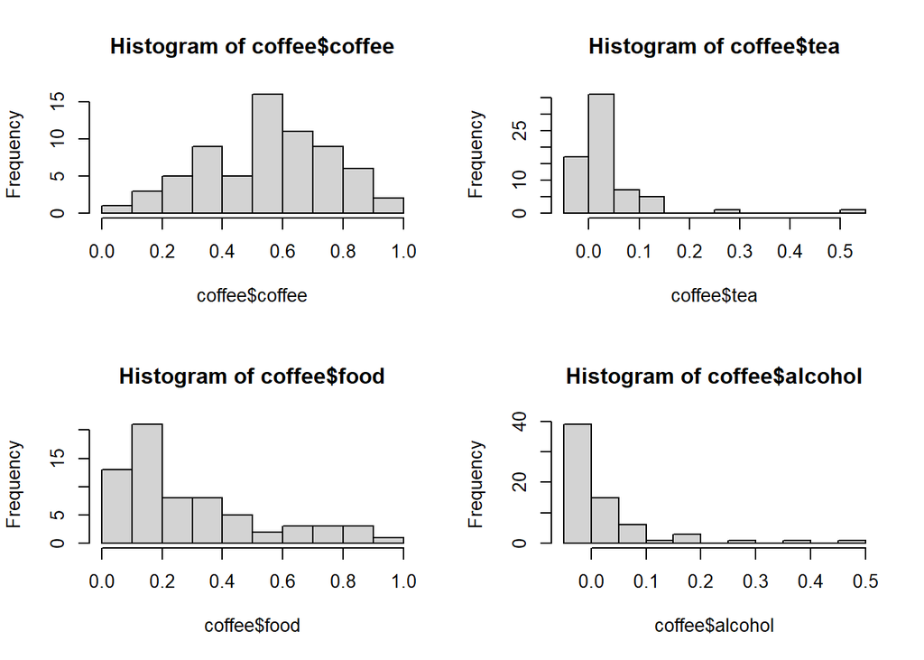

```r
par(mfrow=c(2,2))

hist(coffee$coffee)
hist(coffee$tea)
hist(coffee$food)
hist(coffee$alcohol)
```

```r
dev.off()
```

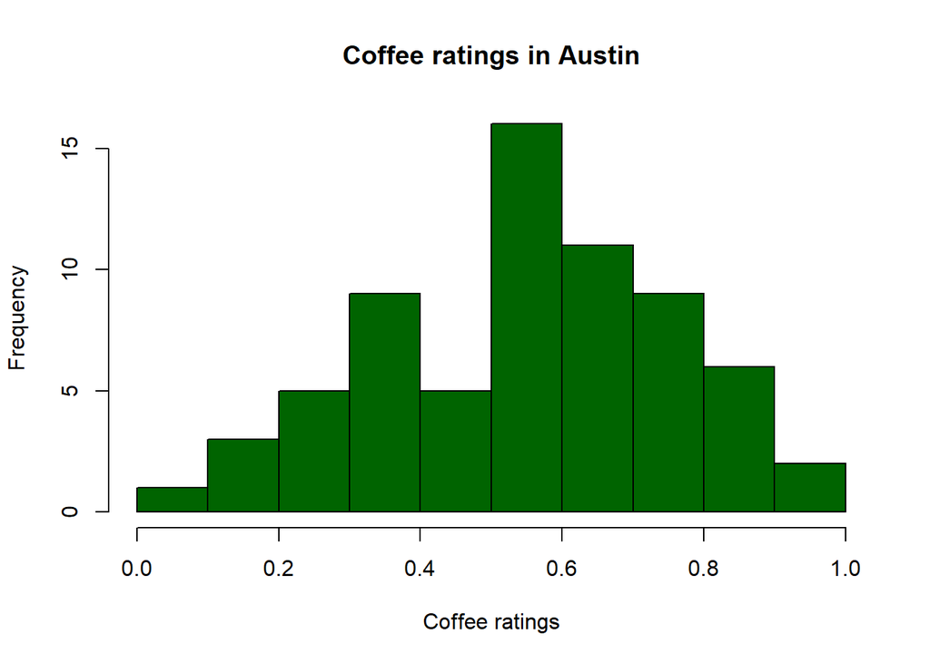

```r
# colored histogram with specified number of bins
hist(coffee$coffee,
     breaks=8,
     col="darkgreen",
     xlab="Coffee ratings",
     main="Coffee ratings in Austin")
```

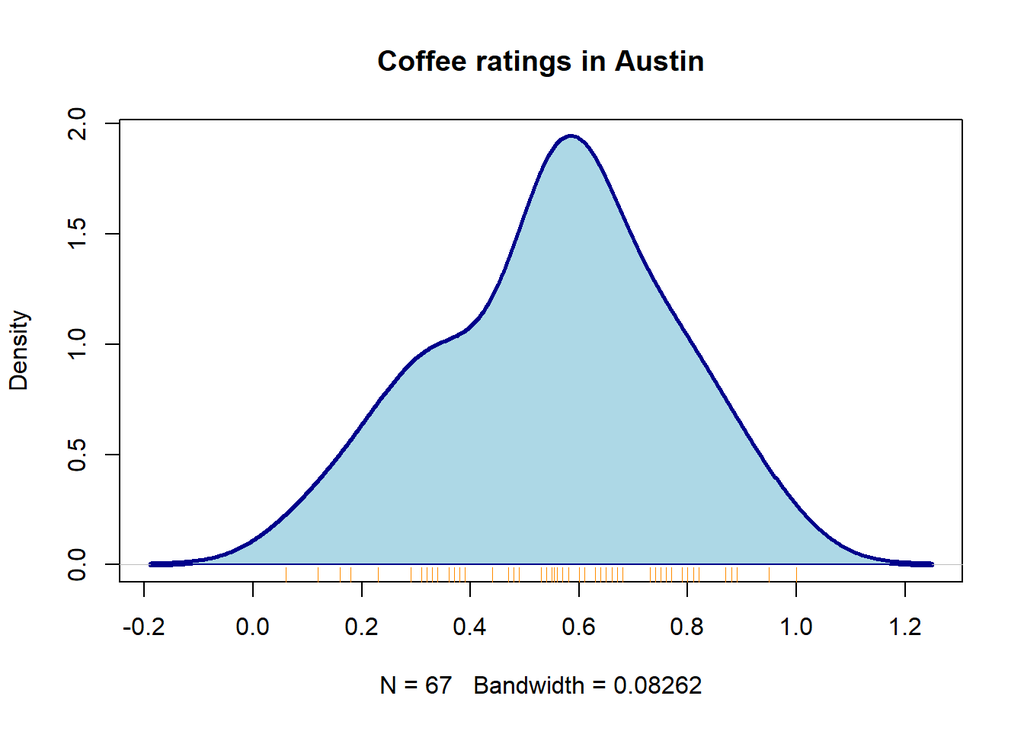

```r
# Kernel density plot with rug plot
d <- density(coffee$coffee) # returns the density data
plot(d,  main="Coffee ratings in Austin", col="darkblue", lwd=4)
polygon(d, col="lightblue", border="darkblue")
rug(coffee$coffee, col="darkorange")
```

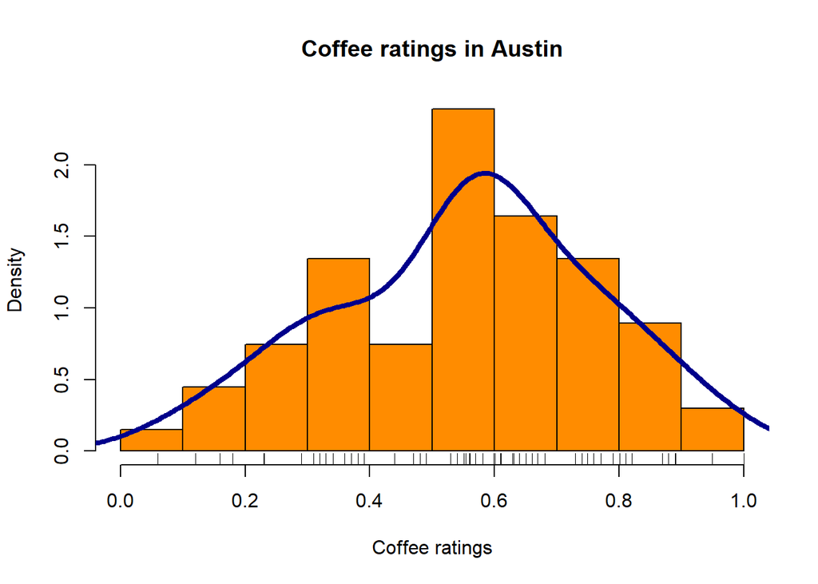

```r
# colored histogram with rug plot and density plot
hist(coffee$coffee,
     freq=FALSE,
     breaks=10,
     col="darkorange",
     xlab="Coffee ratings",
     main="Coffee ratings in Austin")
rug(jitter(coffee$coffee))
lines(density(coffee$coffee), col="darkblue", lwd=4)
```

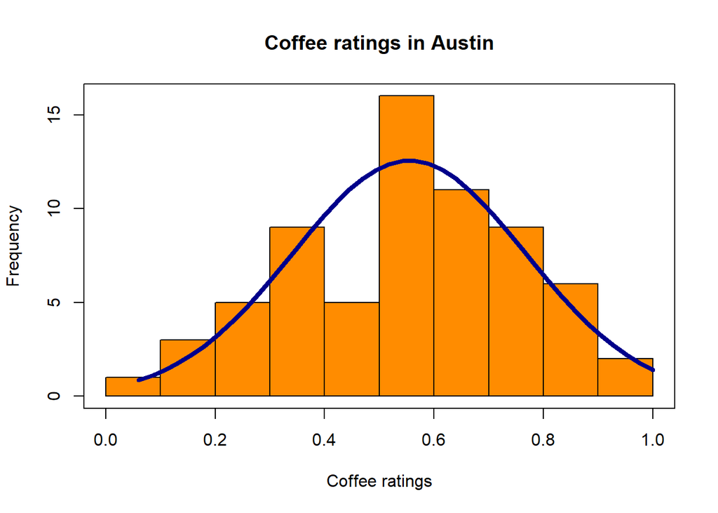

```r
# histogram with superimposed normal curve
x <- coffee$coffee
h <- hist(x,
        breaks=10,
        col="darkorange",
        xlab="Coffee ratings",
        main="Coffee ratings in Austin")
xfit<-seq(min(x),max(x),length=40)
yfit<-dnorm(xfit,mean=mean(x),sd=sd(x))
yfit <- yfit*diff(h$mids[1:2])*length(x)
lines(xfit, yfit, col="darkblue", lwd=4)
box()
```

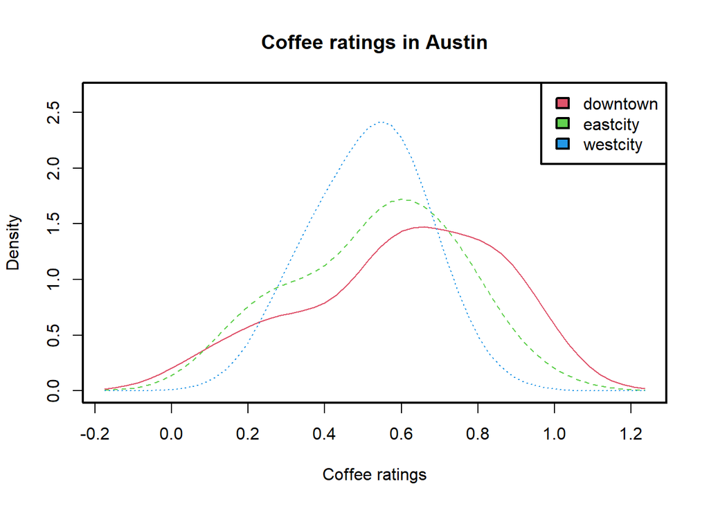

```r
# Comparing density plots
library(sm)
par(lwd=2)
sm.density.compare(coffee$coffee, coffee$cityarea, xlab="Coffee ratings")
title(main="Coffee ratings in Austin")

# add legend via mouse click
colfill<-c(2:(2+length(levels(coffee$cityarea))))
legend("topright", levels(coffee$cityarea), fill=colfill)
```

```r
par(lwd=1)
```

## Boxplot, gráficos violino e gráficos de pontos

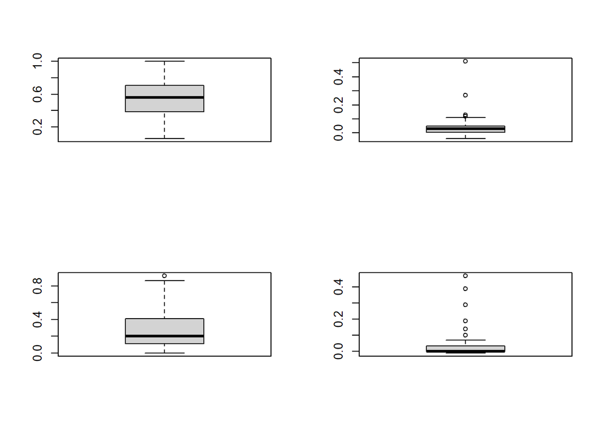

```r
# Generate boxplots
par(mfrow=c(2,2))

boxplot(coffee$coffee)
boxplot(coffee$tea)
boxplot(coffee$food)
boxplot(coffee$alcohol)
```

```r
dev.off()
```

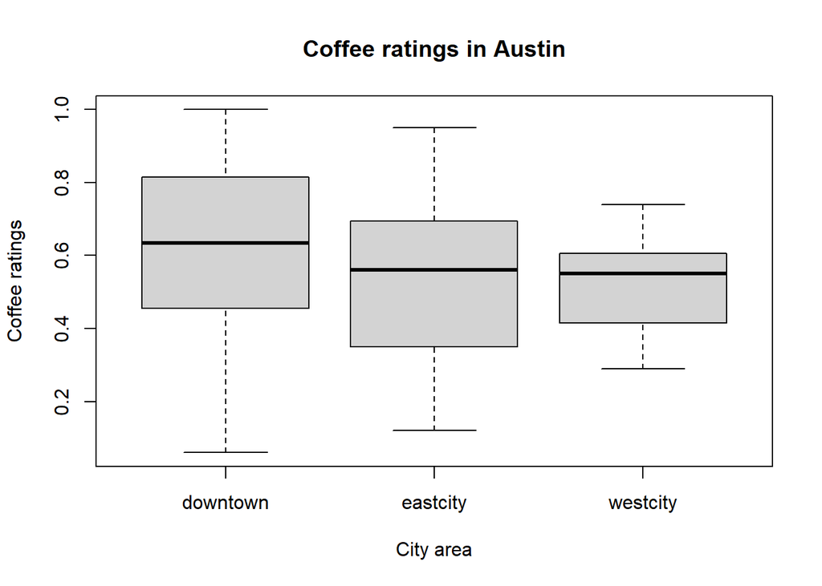

```r
# parallel box plots
boxplot(coffee ~ cityarea, data=coffee,
        main="Coffee ratings in Austin",
        xlab="City area",
        ylab="Coffee ratings")
```

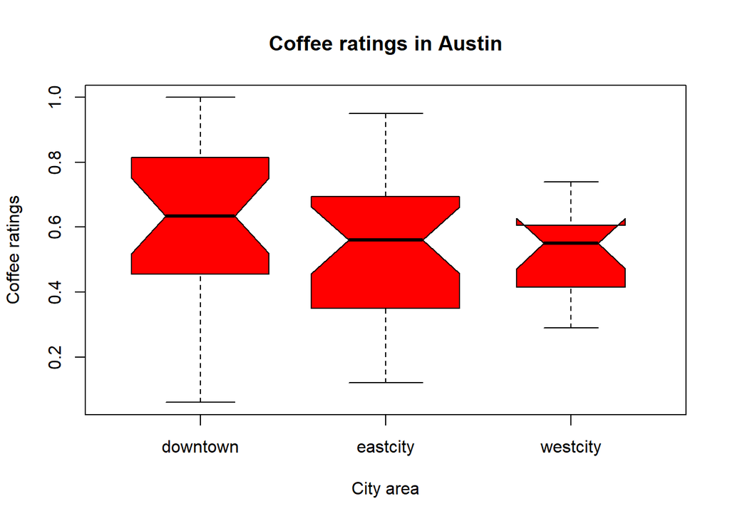

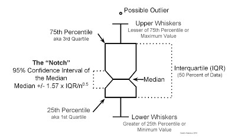

```r
# notched box plots
boxplot(coffee ~ cityarea, data=coffee,
        notch=TRUE,
        varwidth=TRUE,
        col="red",
        main="Coffee ratings in Austin",
        xlab="City area",
        ylab="Coffee ratings")
```

NOTA: Apesar de não ser um teste formal, de acordo com Chambers (1983), a não sobreposição de dois notch indica com 95% de confiança que a mediana das duas amostras difere significativamente.

```r
# Box plots for two crossed factors
table(coffee$cityarea, coffee$popular)
```

```
##
##            FALSE TRUE
##   downtown    21    3
##   eastcity    24    4
##   westcity    14    1
```

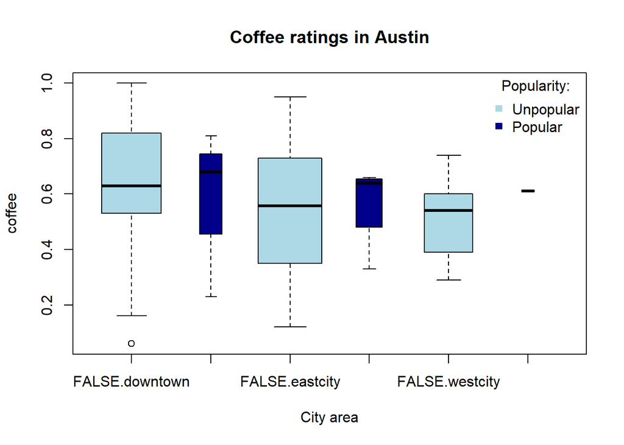

```r
boxplot(coffee ~ popular*cityarea,
        data=coffee,
        varwidth=TRUE,
        col=c("lightblue", "darkblue"),
        main="Coffee ratings in Austin",
        xlab="City area" )
legend("topright", title="Popularity:", pch=c(15, 15), col=c("lightblue", "darkblue"), c("Unpopular", "Popular"),
       bty = "n", title.col="black")
```

O gráfico violino permite combinar o boxplot com o gráfico de densidade

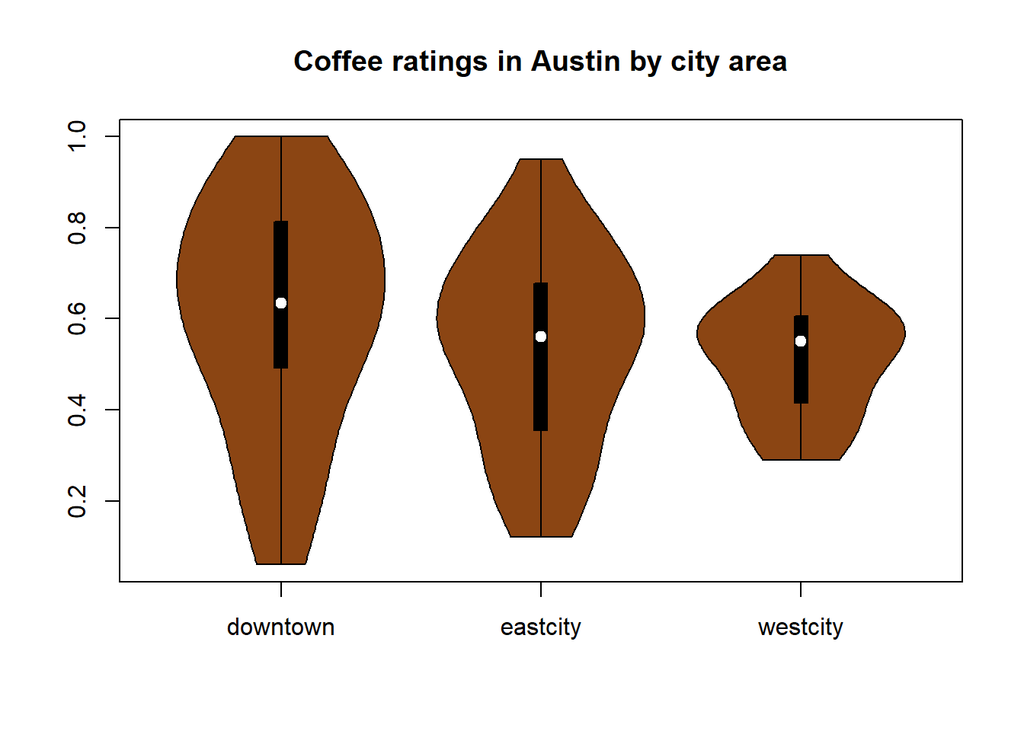

```r
# Violin plots
if (!require("vioplot")) install.packages("vioplot")
library(vioplot)

downtown <- coffee$coffee[coffee$cityarea=="downtown"]
eastcity <- coffee$coffee[coffee$cityarea=="eastcity"]
westcity <- coffee$coffee[coffee$cityarea=="westcity"]
vioplot(downtown, eastcity, westcity,
        names=c("downtown", "eastcity", "westcity"),
        col="saddlebrown")
title("Coffee ratings in Austin by city area")
```

```r
#?vioplot
```

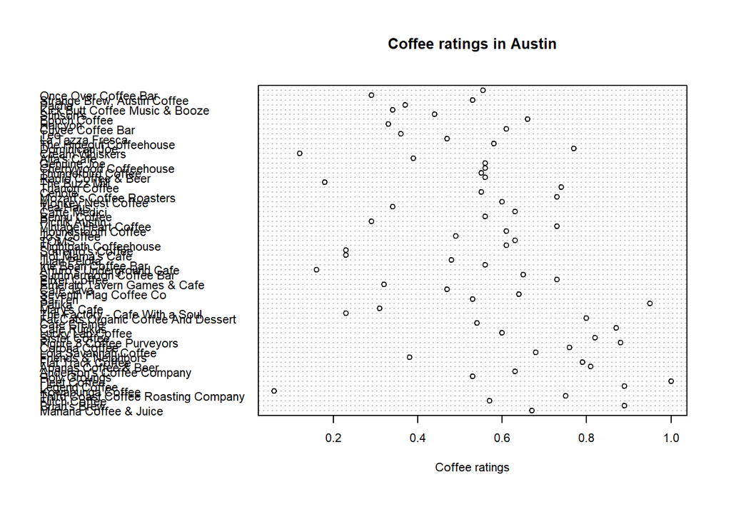

```r
# dot plot
dotchart(coffee$coffee, labels=coffee$coffee_shop_name, cex=.7,
         main="Coffee ratings in Austin",
         xlab="Coffee ratings")
```

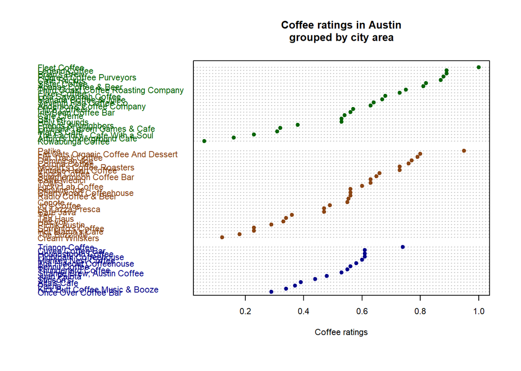

```r
# Dot plot grouped, sorted, and colored
x <- coffee[order(coffee$coffee),]
x$color[x$cityarea=="downtown"] <- "darkgreen"
x$color[x$cityarea=="eastcity"] <- "saddlebrown"
x$color[x$cityarea=="westcity"] <- "darkblue"
dotchart(x$coffee,
         labels = x$coffee_shop_name,
         cex=.7,
         pch=19,
         groups = x$cityarea,
         gcolor = "black",
         color = x$color,
         main = "Coffee ratings in Austin\ngrouped by city area",
         xlab = "Coffee ratings")
```

# 5. Tabelas de frequências

As tabelas de frequências são particularmente úteis para sumariar dados categoriais. As funções mais utilizadas no R para criar este tipo de tabelas são apresentadas no seguinte quadro.

| FUN_table | FUN_desc |
| --- | --- |
| table(var1, var2,… | Cria tabela de frequências (N-way) com N variáveis categoriais |
| xtabs(formula, data | Cria tabela de frequências (N-way) usando uma fórmula e matriz ou DF |
| prop.table(table, margins) | Transforma entradas de uma tabela de frequências em frações marginais |
| margin.table(table, margins) | Faz o sumatório das entradas marginais de uma tabela |
| addmargins(table, margins) | Acrescenta sumários marginais a uma tabela de frequências |
| ftable(table) | Cria tabela de frequências compacta |

```
##  [1] "coffee_shop_name" "cityarea"         "num_reviews"      "popular"
##  [5] "rating"           "ratingMorning"    "ratingLunch"      "ratingAfternoon"
##  [9] "ratingDinner"     "coffee"           "coffee_rec"       "tea"
## [13] "tea_rec"          "food"             "food_rec"         "alcohol"
## [17] "alcohol_rec"      "vibe"             "vibe_rec"         "service"
## [21] "service_rec"      "price"            "price_rec"        "convenience"
## [25] "convenience_rec"  "internet"         "seating"
```

```
## $coffee_rec
## [1] "ordered" "factor"
##
## $tea_rec
## [1] "ordered" "factor"
##
## $food_rec
## [1] "ordered" "factor"
##
## $alcohol_rec
## [1] "ordered" "factor"
##
## $cityarea
## [1] "factor"
##
## $popular
## [1] "logical"
##
## $internet
## [1] "logical"
##
## $seating
## [1] "logical"
```

## A função **table** para tabelas de frequências

```
## coffee_rec
##  Very Bad       Bad        Ok      Good Very Good
##         4        13        33        13         4
```

```
## coffee_rec
##   Very Bad        Bad         Ok       Good  Very Good
## 0.05970149 0.19402985 0.49253731 0.19402985 0.05970149
```

```
## coffee_rec
##  Very Bad       Bad        Ok      Good Very Good
##  5.970149 19.402985 49.253731 19.402985  5.970149
```

## A função **xtabs** para tabelas de frequência

A função **xtabs()** proporciona um método alternativo para criar tabelas de frequência no R. Esta função tem como argumento principal um objeto R do tipo *fórmula*.

```
## alcohol_rec
##  Very Bad       Bad        Ok      Good Very Good
##         3         0        47        11         6
```

# 6. Visualização de frequências

## Gráficos de barras simples

```r
names(coffee)
```

```
##  [1] "coffee_shop_name" "cityarea"         "num_reviews"      "popular"
##  [5] "rating"           "ratingMorning"    "ratingLunch"      "ratingAfternoon"
##  [9] "ratingDinner"     "coffee"           "coffee_rec"       "tea"
## [13] "tea_rec"          "food"             "food_rec"         "alcohol"
## [17] "alcohol_rec"      "vibe"             "vibe_rec"         "service"
## [21] "service_rec"      "price"            "price_rec"        "convenience"
## [25] "convenience_rec"  "internet"         "seating"
```

```r
coffee$convenience_rec
```

```
##  [1] Ok        Ok        Good      Ok        Very Good Good      Bad
##  [8] Bad       Ok        Good      Bad       Bad       Very Good Ok
## [15] Good      Good      Very Bad  Good      Ok        Good      Ok
## [22] Ok        Ok        Ok        Very Good Bad       Ok        Good
## [29] Bad       Ok        Ok        Ok        Ok        Good      Very Bad
## [36] Bad       Ok        Ok        Very Good Ok        Ok        Ok
## [43] Bad       Good      Ok        Ok        Good      Ok        Ok
## [50] Bad       Bad       Ok        Good      Ok        Ok        Very Bad
## [57] Bad       Ok        Good      Ok        Ok        Good      Ok
## [64] Ok        Ok        Bad       Ok
## Levels: Very Bad < Bad < Ok < Good < Very Good
```

```r
mytable_1 <- table(coffee$convenience_rec)
mytable_1
```

```
##
##  Very Bad       Bad        Ok      Good Very Good
##         3        12        34        14         4
```

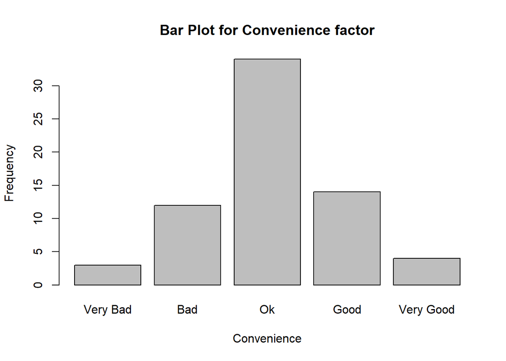

```r
# Simple vertical barplot
barplot(mytable_1,
        main="Bar Plot for Convenience factor",
        xlab="Convenience", ylab="Frequency")
```

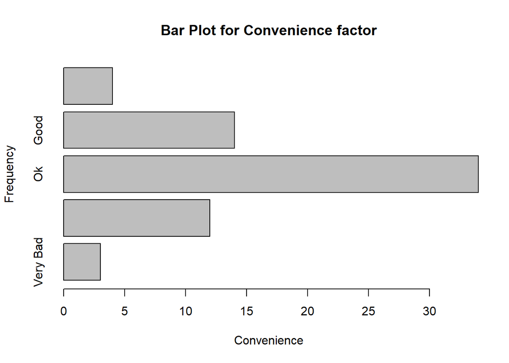

```r
# Simple horizontal bar plot
barplot(mytable_1,
        main="Bar Plot for Convenience factor",
        xlab="Convenience", ylab="Frequency",
        horiz=TRUE)
```

```r
# Bar plot for sorted mean values
means <- aggregate(coffee$rating, by=list(city_area=coffee$cityarea), FUN=mean)
means
```

```
##   city_area        x
## 1  downtown 4.538333
## 2  eastcity 4.139380
## 3  westcity 3.916667
```

```r
means <- means[order(means$x),]
means
```

```
##   city_area        x
## 3  westcity 3.916667
## 2  eastcity 4.139380
## 1  downtown 4.538333
```

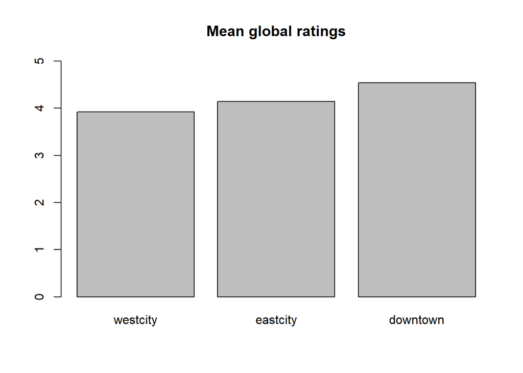

```r
barplot(means$x,
        names.arg=means$city_area,
        main = "Mean global ratings",
        beside=TRUE,
        ylim=c(0,5))
```

## Pie charts

```r
mytable_4 <- table(coffee$convenience_rec)
names(mytable_4)
```

```
## [1] "Very Bad"  "Bad"       "Ok"        "Good"      "Very Good"
```

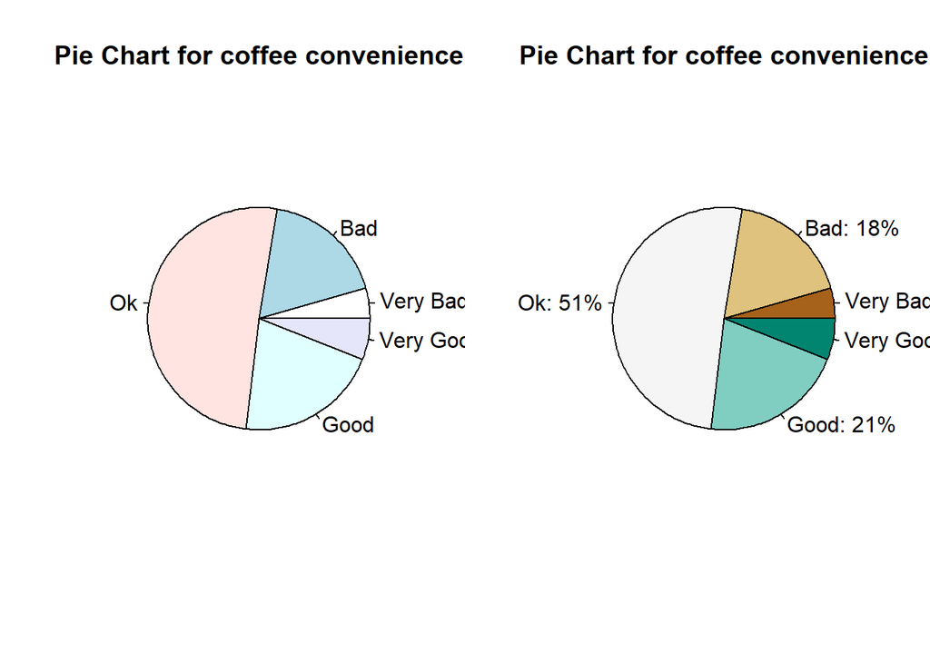

```r
par(mfrow=c(1,2))
pie(mytable_4, labels = names(mytable_4),
    main="Pie Chart for coffee convenience")

pct <- round(prop.table(mytable_4)*100,0)
lbls <-paste(names(mytable_4), pct, sep=": ")
lbls <- paste(lbls,"%", sep="")

library(RColorBrewer)
pie(mytable_4,labels = lbls, col= brewer.pal(5,  "BrBG"),
    main="Pie Chart for coffee convenience")
```

```r
dev.off()
```

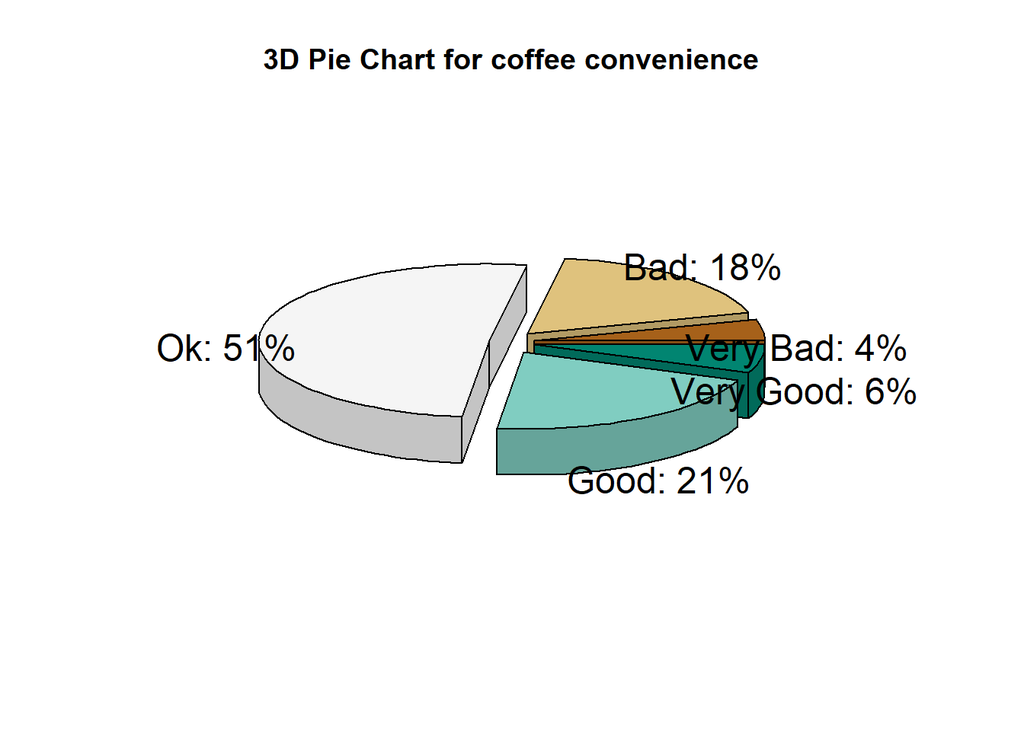

```r
if (!require("plotrix")) install.packages("plotrix")
library(plotrix)
pie3D(mytable_4, col= brewer.pal(5,  "BrBG"),
      labels=lbls, explode=0.1,
      main="3D Pie Chart for coffee convenience")
```

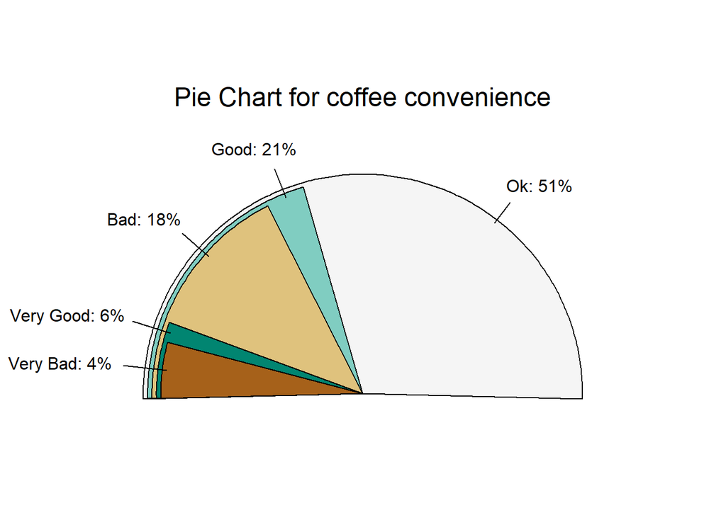

```r
if (!require("plotrix")) install.packages("plotrix")
library(plotrix)
fan.plot(mytable_4, labels = lbls, col= brewer.pal(5,  "BrBG"), main="Pie Chart for coffee convenience")
```